# Midterm Class 1

Today we are going to work through data wrangling, visualization, and pattern identification/description. We are also going to pick up some particularly useful tools for this type of data and for your report.

*Since making these plots in class, I have gone through and done some factor recoding and cleaned up the axis labels on a few of the plots. This is to provide you with examples of how to do this with your own data. The expectation is that all of the plots in your Midterm Report will be polished according to the Visualization Guidelines in the the Assignment Description.*

# Which Dataset are you using???

Let’s read in the data:

```r
#code to read in data
# EJI
library(sf)
library(tidyverse)
library(ggthemes)
library(viridis)
library(patchwork)

eji_data <- st_read("~/Dropbox/!Middlebury/Teaching/STAT 118/S2026/S2026_R_Proj/midterm/eji_sf.gpkg")
# YRBS
yrbs_data <- read_csv("~/Dropbox/!Middlebury/Teaching/STAT 118/S2026/S2026_R_Proj/midterm/yrbss_2024.csv")
```

# Exploratory Data Analysis

The process we will practice today is called **exploratory data analysis (EDA)**.

EDA is the process of using summaries and visualizations to discover patterns in data and develop questions about those patterns.

**The workflow usually looks something like this:**

→ Understand the dataset  
→ Ask questions  
→ Create plots  
→ Identify patterns  
→ Interpret what those patterns might mean

This process is **iterative**.

# Generating Questions

Now that we have looked at the structure of the dataset, the next step is to think about questions we might ask.

**Some common types of exploratory questions include:**

- Do groups differ from one another?
- Are two variables related?
- What are the highest or lowest values?
- How does something change across categories?

## Matching the Question with the Visualization

Once we have a question, the next step is to think about what kind of visualization might help answer that question.

Different kinds of questions are best answered by different kinds of plots.

| Question type | Useful plot |
| --- | --- |
| Comparing groups | Bar chart, boxplot |
| Relationship between variables | Scatterplot/Heatmap |
| Distribution of values | Histogram, density plot, boxplot, violin plot |
| Geographical data | Choropleth map |

[Here](https://www.data-to-viz.com/) is an excellent resource for matching your data type and question to the many plot options out there.

# Let’s go through some iterations of the process

→ Understand the dataset  
→ Ask questions  
→ Create plots  
→ Identify patterns  
→ Interpret what those patterns might mean

*Your first plots do not need to be perfect. Exploratory plots are tools for helping us see patterns in the data.*

## EJI

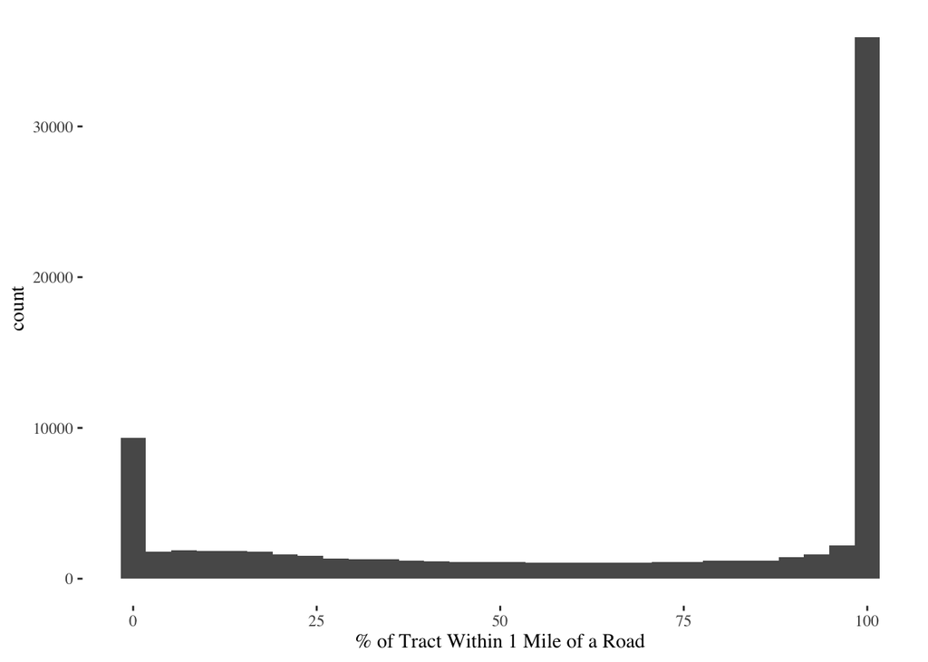

```r
#what variables should we use?
# E_ROAD % tract within 1-mile to road
# E_DSLPM
# E_ASTHMA % people in tract with asthma


# start with histogram of both variables

eji_data |>
  ggplot(aes(x=E_ROAD)) +
  geom_histogram() +
  labs(x= "% of Tract Within 1 Mile of a Road") +
  theme_tufte()
```

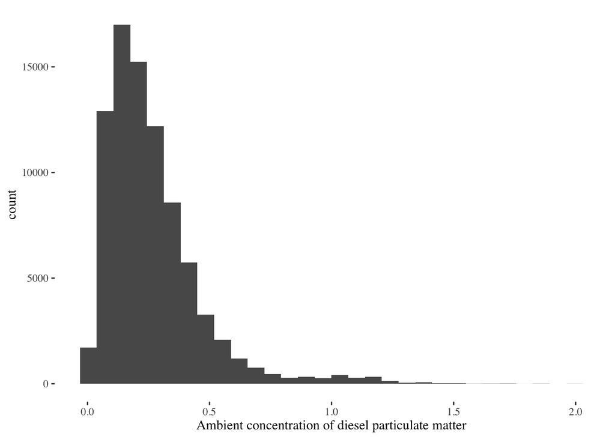

```r
eji_data |>
  ggplot(aes(x=E_DSLPM)) +
  geom_histogram() +
  labs(x= "Ambient concentration of diesel particulate matter") +
  theme_tufte()
```

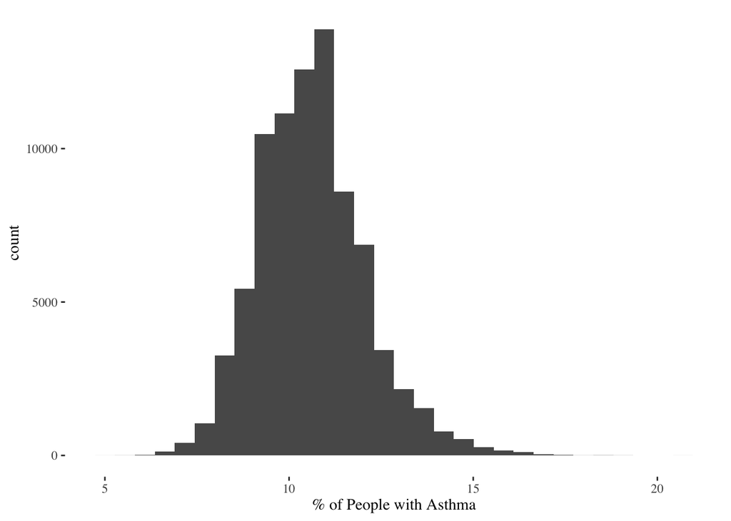

```r
eji_data |>
  ggplot(aes(x=E_ASTHMA)) +
  geom_histogram() +
  labs(x= "% of People with Asthma") +
  theme_tufte()
```

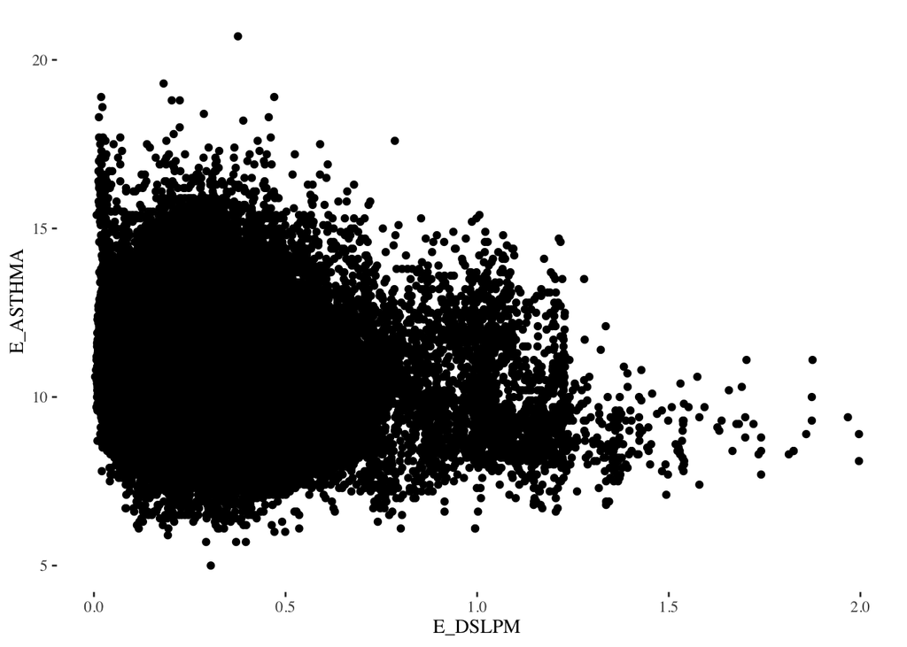

```r
# next scatterplot (of all data)

eji_data |>
  ggplot(aes(x=E_DSLPM, y=E_ASTHMA)) +
  geom_point() +
  theme_tufte()
```

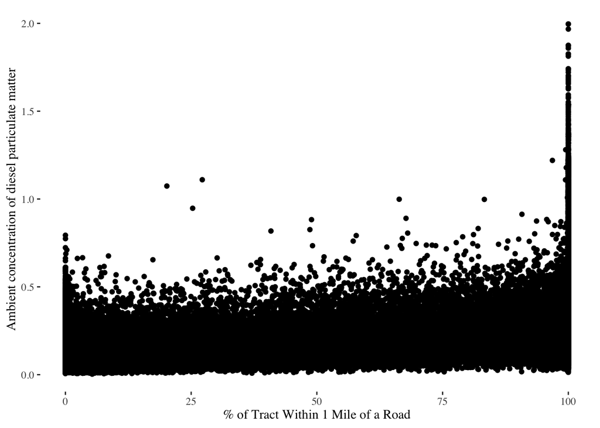

```r
eji_data |>
  ggplot(aes(y=E_DSLPM, x=E_ROAD)) +
  geom_point() +
  labs(x= "% of Tract Within 1 Mile of a Road",
       y= "Ambient concentration of diesel particulate matter") +
  theme_tufte()
```

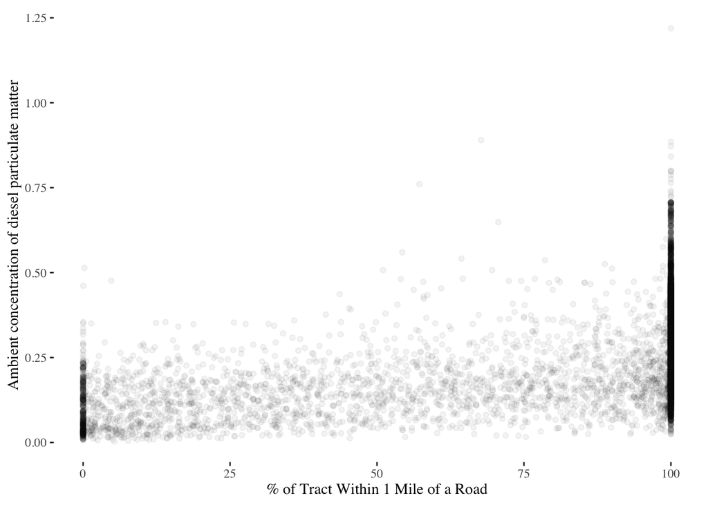

```r
# next redo with subset for specific state

eji_data |>
  filter(STATE_NAME=="California") |>
  ggplot(aes(y=E_DSLPM, x=E_ROAD)) +
  geom_point(alpha=0.05) +
  labs(x= "% of Tract Within 1 Mile of a Road",
       y= "Ambient concentration of diesel particulate matter") +
  theme_tufte()
```

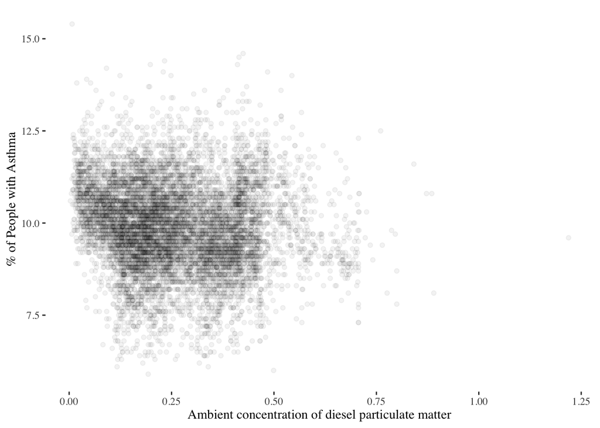

```r
eji_data |>
  filter(STATE_NAME=="California") |>
  ggplot(aes(x=E_DSLPM, y=E_ASTHMA)) +
  labs(x= "Ambient concentration of diesel particulate matter",
       y= "% of People with Asthma") +
  geom_point(alpha=0.05) +
  theme_tufte()
```

### Data density

In a lot of cases the EJI has so much data that you actually cannot see through the cloud of points. What are some ways that we can handle this?

#### Density plots

We can look at data density using a variety of techniques, including setting a lower `alpha`, using `geom_density_2d`/`geom_density_2d_filled`, or using `geom_hex`.

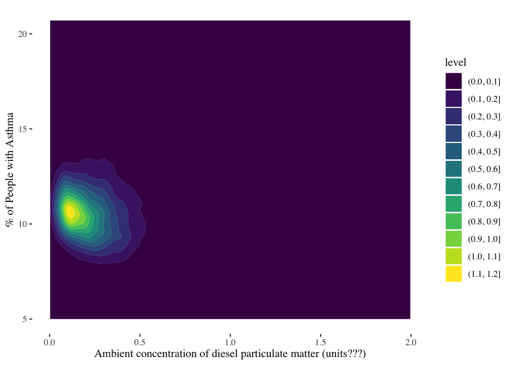

```r
# multiple ways to view dense data with the same plot

# next scatterplot (of all data)

eji_data |>
  ggplot(aes(x=E_DSLPM, y=E_ASTHMA)) +
  geom_density_2d_filled() +
  labs(x= "Ambient concentration of diesel particulate matter (units???)",
       y= "% of People with Asthma") +
  theme_tufte()
```

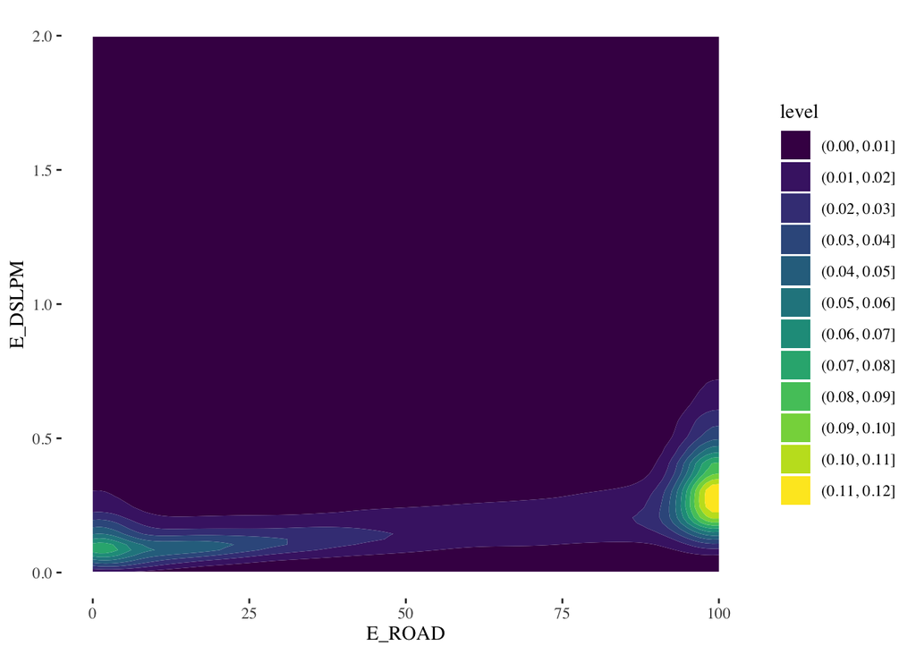

```r
eji_data |>
  ggplot(aes(y=E_DSLPM, x=E_ROAD)) +
  geom_density_2d_filled() +
  theme_tufte()
```

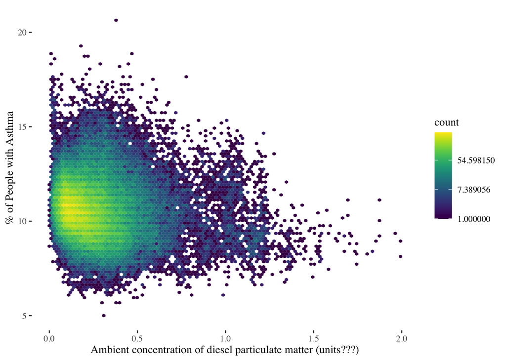

```r
eji_data |>
  ggplot(aes(x=E_DSLPM, y=E_ASTHMA)) +
  geom_hex(bins=100) +
  scale_fill_viridis(trans="log")+
  labs(x= "Ambient concentration of diesel particulate matter (units???)",
       y= "% of People with Asthma") +
  theme_tufte()
```

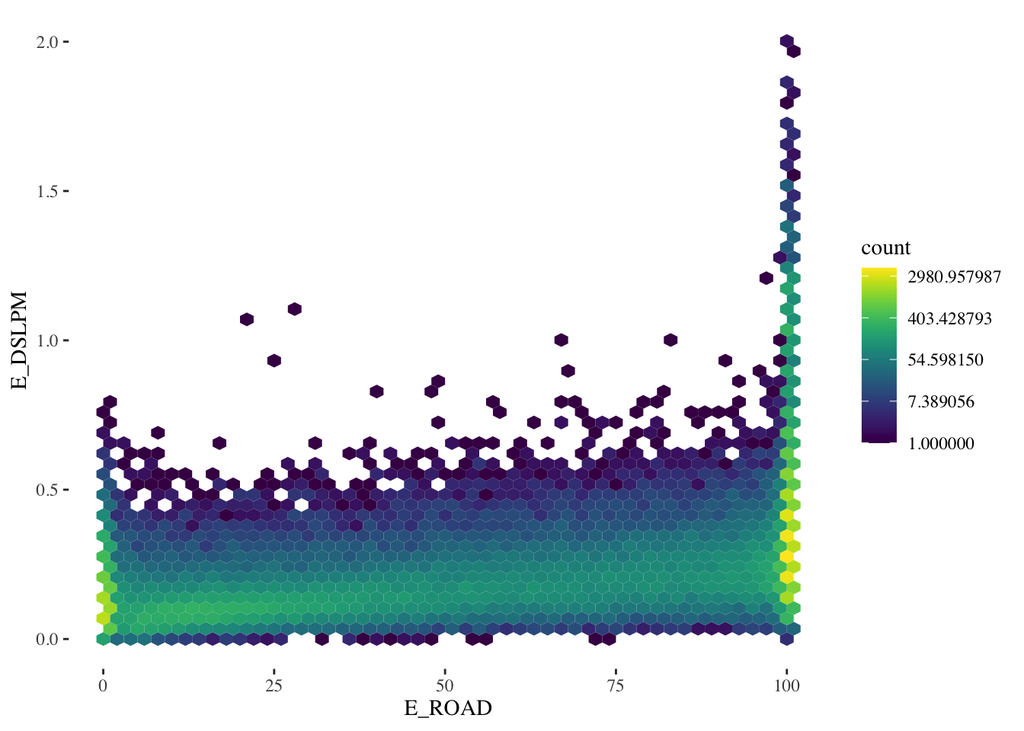

```r
eji_data |>
  ggplot(aes(y=E_DSLPM, x=E_ROAD)) +
  geom_hex(bins=50) +
  scale_fill_viridis(trans="log")+
  theme_tufte()
```

#### Trend lines

To help make a pattern clear from a cloud of data it cane be useful to add a trend line using `geom_smooth`. Look at the help documentation to understand what statistical methods are generating the trendline.

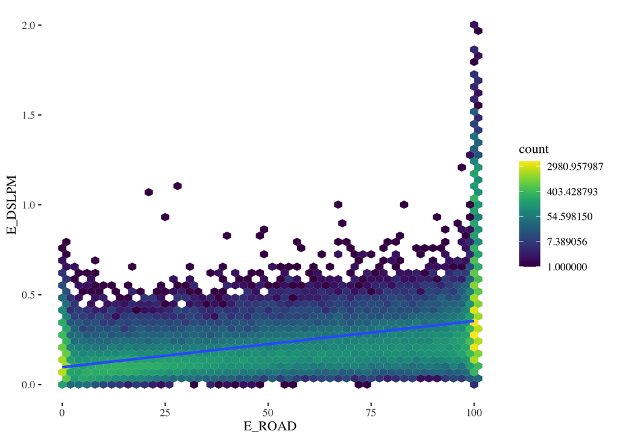

```r
# add trendline with geom_smooth()

eji_data |>
  ggplot(aes(y=E_DSLPM, x=E_ROAD)) +
  geom_hex(bins=50) +
  geom_smooth(method="lm") +
  scale_fill_viridis(trans="log") +
  theme_tufte()
```

### Creating groups from continuous data

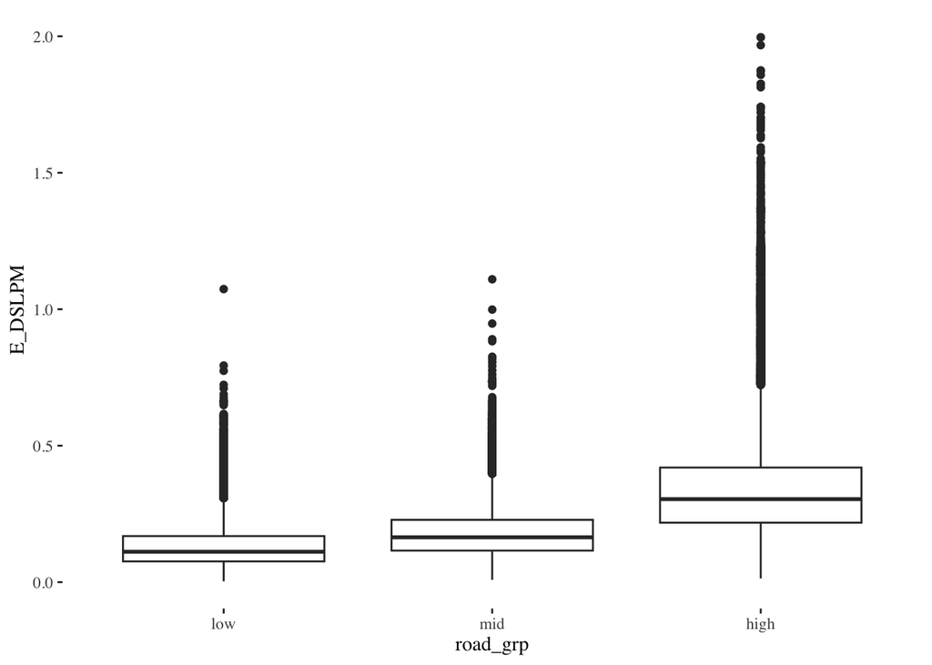

```r
eji_data <- eji_data |>
  mutate(road_grp = as.factor(case_when(E_ROAD <= 25 ~ "low",
                              E_ROAD > 25 & E_ROAD < 75 ~ "mid",
                              E_ROAD >= 75 ~ "high"))) |>
  mutate(road_grp = fct_relevel(road_grp, c("low", "mid", "high"))) # relevel factor

eji_data |>
  drop_na(road_grp) |>
  ggplot(aes(x=road_grp, y=E_DSLPM)) +
  geom_boxplot() +
  theme_tufte()
```

Creating groups from continuous data can be a great way to tease out patterns. While we have gone over all of the tools for doing this, you haven’t been asked to put them together quite this way before.

## Discussion

In your groups: - Share a pattern you’ve already noticed in your dataset. - What question does that pattern raise? - Is there a visualization or technique from today’s lesson that could help you investigate it? - What would your next step be?

**Write down one concrete next step**

## YRBSS

### Proportionality

There is a disproportionate distribution of data in many instances, especially of the YRBS data. This means that raw count is going to make it difficult to see patterns, and that proportions need to be considered instead.

#### Proportional Bar Graph

Let’s start with a basic proportional bar graph.

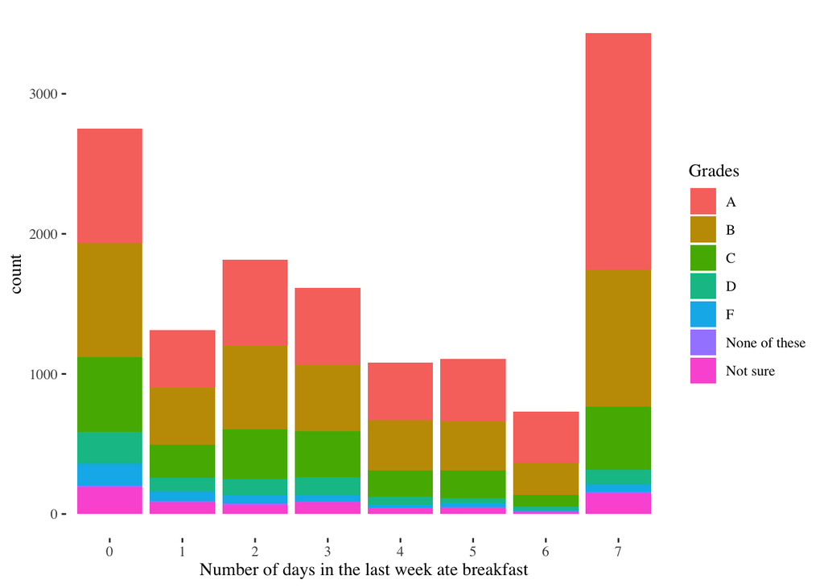

```r
# Q75 - How many days did you eat breakfast in the past 7 days
# Q87 - During the past 12 months how would you describe your grades in school

# first stacked with position="stack"

yrbs_data_mod <-yrbs_data |>
  drop_na(Q75, Q87) |>
  mutate(Q75_fac=as.factor(Q75),
         Q87_fac=as.factor(Q87)) |>
  mutate(Q75_fac=fct_recode(Q75_fac, "0"="1", "1"="2", "2"="3",
                                    "3"="4", "4"="5", "5"="6",
                                    "6"="7", "7"="8"),
         Q87_fac = fct_recode(Q87_fac, "A"="1", "B"="2", "C"="3",
                              "D"="4", "F"="5", "None of these"="6",
                              "Not sure"="7"))


yrbs_data_mod |>
  ggplot(aes(x=Q75_fac, fill=Q87_fac,
             group=Q87_fac)) +
  geom_bar(position="stack") +
  labs(x= "Number of days in the last week ate breakfast",
       fill= "Grades") +
  theme_tufte()
```

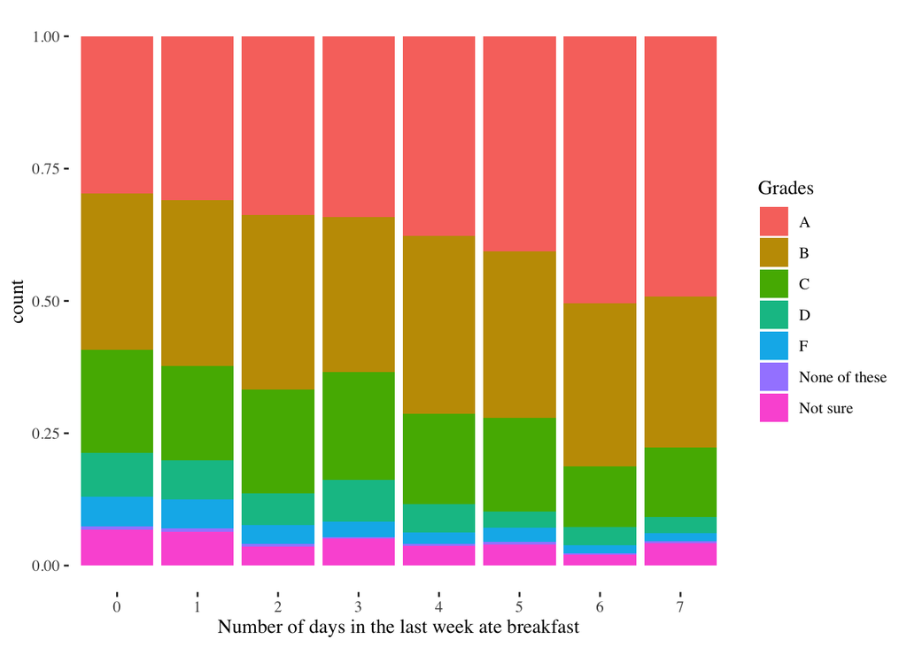

```r
# now proportional with position="fill"
yrbs_data_mod |>
  ggplot(aes(x=Q75_fac, fill=Q87_fac,
             group=Q87_fac)) +
  geom_bar(position="fill") +
  labs(x= "Number of days in the last week ate breakfast",
       fill= "Grades") +
  theme_tufte()
```

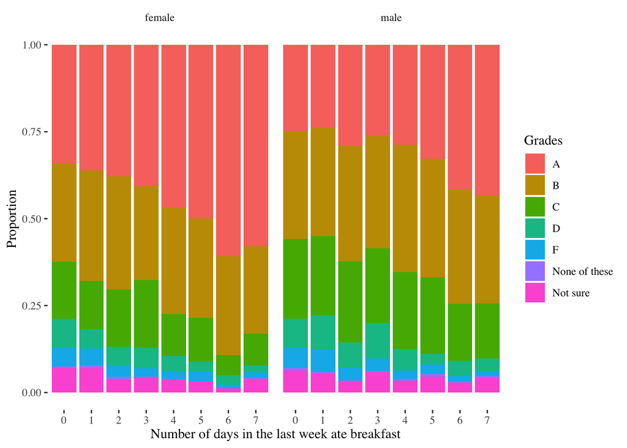

```r
# Don't forget about faceting!
# let's add a facet_wrap() (Q2 is sex, which could work)
yrbs_data_mod |>
  drop_na(Q75, Q87, Q2) |>
  mutate(gender = fct_recode(as.factor(Q2), "female"="1", "male"="2")) |>
  ggplot(aes(x=Q75_fac, fill=Q87_fac, group=Q87_fac)) +
  geom_bar(position="fill") +
  labs(x= "Number of days in the last week ate breakfast",
       fill= "Grades",
       y= "Proportion") +
  theme_tufte() +
  facet_wrap(~gender)
```

#### How to calculate proportions

If we want to work with these variables outside of something that does all of the calculations for you we will need to calcualte the proportions ourselves.

```r
# Q75 - How many days did you eat breakfast in the past 7 days
# Q87 - During the past 12 months how would you describe your grades in school

# stashing this here for myself in case I cannot conjur this up at 8am
# yrbs_data |>
#   drop_na(Q75, Q87) |>
#   count(Q75, Q87) |> #calculate # in each category combo
#   group_by(Q75) |> # group by breakfast group
#   mutate(prop = n / sum(n))  # within each breakfast group divide number in combo category by total number in breakfast category

yrbs_data |>
  drop_na(Q75, Q87) |>
  count(Q75, Q87) |>
  group_by(Q75) |>
  mutate(prop=n/sum(n))
```

```
# A tibble: 56 × 4
# Groups:   Q75 [8]
     Q75   Q87     n    prop
   <dbl> <dbl> <int>   <dbl>
 1     1     1   817 0.297
 2     1     2   812 0.295
 3     1     3   536 0.195
 4     1     4   228 0.0829
 5     1     5   154 0.0560
 6     1     6    16 0.00582
 7     1     7   188 0.0683
 8     2     1   406 0.310
 9     2     2   411 0.314
10     2     3   234 0.178
# ℹ 46 more rows
```

*In class we only had time to do this with 2 variables, so I’ve done it with a 3rd variable here:*

```r
# do it again with sex included as a variable

yrbs_data |>
  drop_na(Q75, Q87, Q2) |>
  count(Q75, Q87, Q2) |>
  group_by(Q75, Q2) |>
  mutate(prop=n/sum(n))
```

```
# A tibble: 111 × 5
# Groups:   Q75, Q2 [16]
     Q75   Q87    Q2     n   prop
   <dbl> <dbl> <dbl> <int>  <dbl>
 1     1     1     1   493 0.341
 2     1     1     2   320 0.248
 3     1     2     1   409 0.283
 4     1     2     2   399 0.310
 5     1     3     1   235 0.163
 6     1     3     2   297 0.230
 7     1     4     1   121 0.0838
 8     1     4     2   106 0.0822
 9     1     5     1    78 0.0540
10     1     5     2    75 0.0582
# ℹ 101 more rows
```

#### Proportional Heatmap

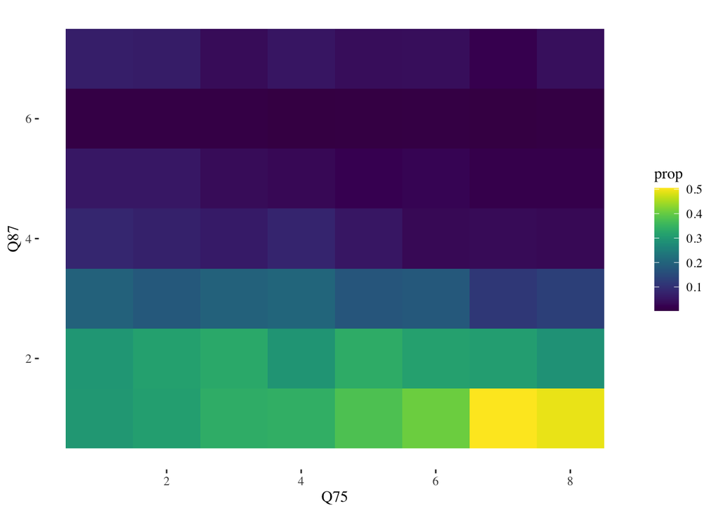

```r
# make heatmap with proportion calculations above

yrbs_data |>
  drop_na(Q75, Q87) |>
  count(Q75, Q87) |>
  group_by(Q75) |>
  mutate(prop=n/sum(n)) |>
  ggplot(aes(x=Q75, y=Q87, fill=prop)) +
  geom_tile() +
  scale_fill_viridis() +
  theme_tufte()
```

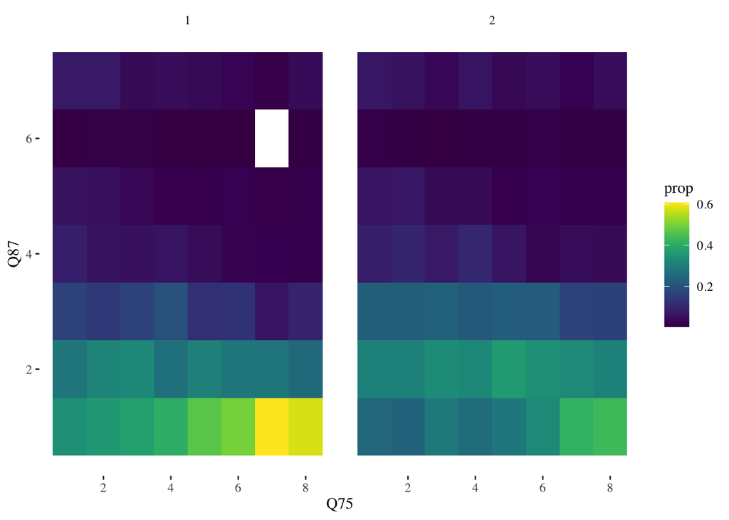

```r
# do it again with sex
yrbs_data |>
  drop_na(Q75, Q87, Q2) |>
  count(Q75, Q87, Q2) |>
  group_by(Q75, Q2) |>
  mutate(prop=n/sum(n)) |>
  ggplot(aes(x=Q75, y=Q87, fill=prop)) +
  geom_tile() +
  scale_fill_viridis() +
  theme_tufte() +
  facet_wrap(~Q2)
```

*Here is an example o the other version I was talking about, where you add a third variable as color rather than the proportion that falls within each combination category.*

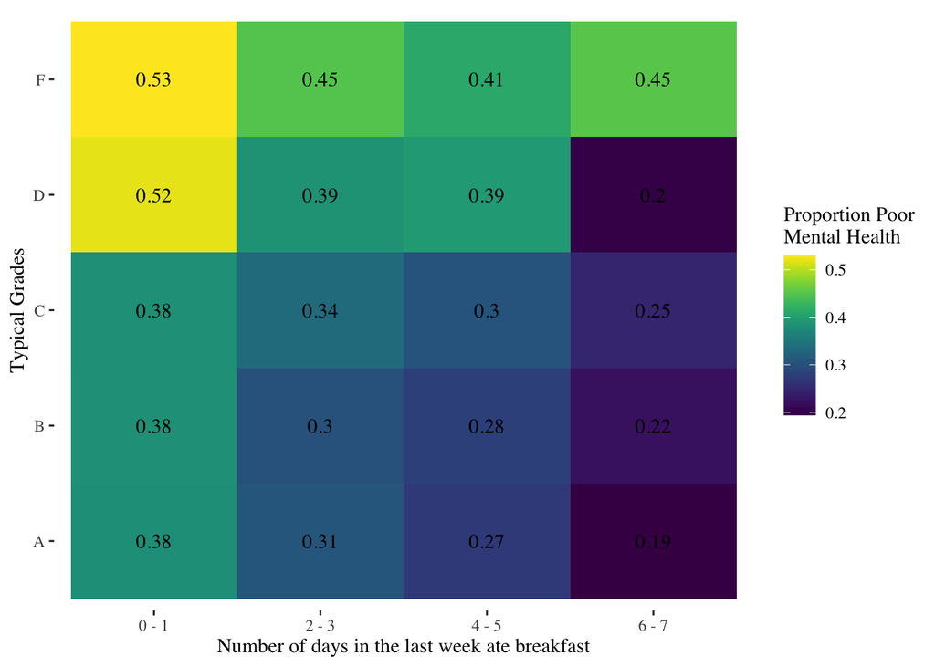

```r
# we are going to add mental health
# Q84 - During the past 30 days, how often was your mental health not good?

yrbs_data |>
  drop_na(Q75, Q87, Q84) |> # remove NAs from all Qs used in subsequent code
  mutate(Q75_bin = case_when(Q75 ==1 | Q75 == 2 ~ "0 - 1", # bin categories of breakfast
                             Q75 == 3 | Q75 == 4 ~ "2 - 3",
                             Q75 == 5 | Q75 == 6 ~ "4 - 5",
                             Q75 == 7 | Q75 == 8 ~ "6 - 7"),
         mental_health = case_when(Q84 <= 3 ~ "Infrequent", # turn mental health into 2 categories
                                   Q84 > 3 ~ "Frequent")) |>
   mutate(Q87_fac=as.factor(Q87)) |>
  mutate(Q87_fac = fct_recode(Q87_fac, "A"="1", "B"="2", "C"="3",
                              "D"="4", "F"="5", "None of these"="6",
                              "Not sure"="7")) |>
  filter(Q87 <= 5) |> # filter out the meaningless categories using the numeric Q87
  count(Q75_bin, Q87_fac, mental_health) |> # count the number of people that fall within each 3 category combo
  group_by(Q75_bin, Q87_fac) |> # regroup by breakfast bin and grades
  mutate(prop = n / sum(n)) |> # calculate the proportion of each mental health group relative to total number of people that fall within each Q75_bin/Q87 category combination
  filter(mental_health == "Frequent") |> #filter for only the proportion bad mental health
  ggplot(aes(x=as.factor(Q75_bin),
             y=Q87_fac,
             fill= prop)) +
  geom_tile() +
  geom_text(aes(label=round(prop,2))) + #use round() to control significant digits in label
  scale_fill_viridis() +
   labs(x= "Number of days in the last week ate breakfast",
       y= "Typical Grades",
       fill= "Proportion Poor\nMental Health") + # use \n for line break in label
  theme_tufte()
```

### Identify and describe patterns

When we look at a plot, the first step is to describe what we see.

Examples of descriptive observations include:

- One group has higher values than another group
- The values increase across categories
- There appears to be a relationship between two variables
- Try to focus on what the data show, rather than explaining why.

Questions you should be answering with your descriptive observations:

- What does the plot show?
- What doesn’t it show?
- What questions does it answer?
- What questions does it raise?

## Discussion

In small groups: - Share one question you’re investigating in your midterm project. - Are there groups or categories in your data that you want to compare? - Would comparing counts or proportions help answer your question? Why? - Could adding another variable reveal something interesting?

**Write down one concrete next step**

# Multi-panel figures with faceting or `patchwork`

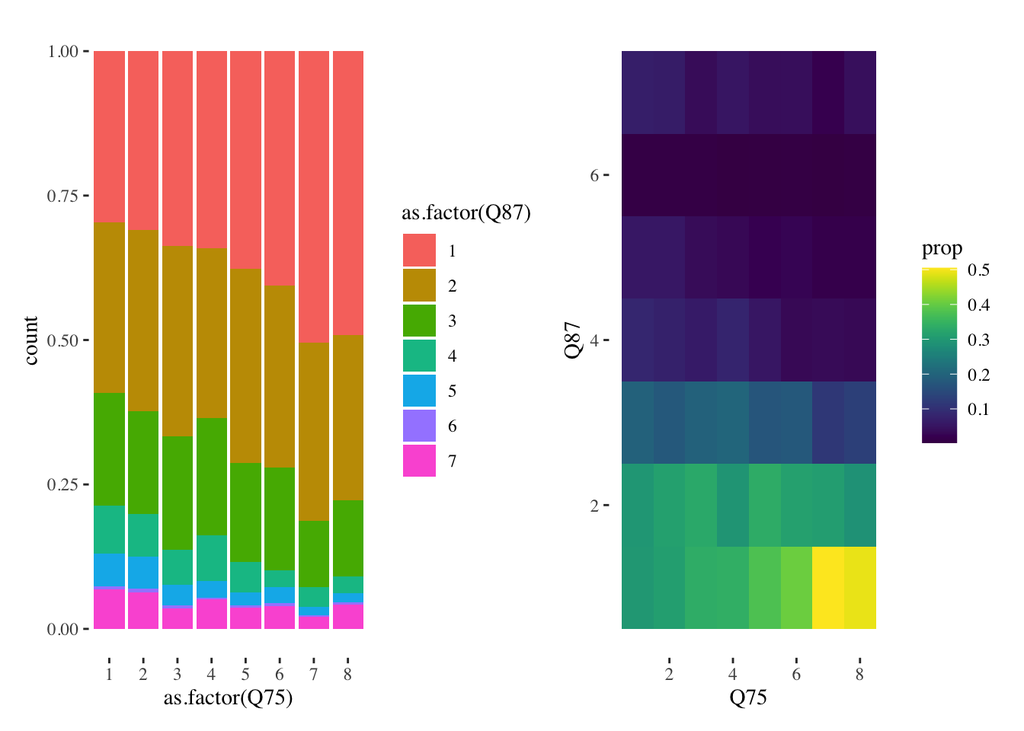

```r
# grab 2 plots from above and put into panel.
plot1 <- yrbs_data |>
  drop_na(Q75, Q87) |>
  ggplot(aes(x=as.factor(Q75), fill=as.factor(Q87),
             group=as.factor(Q87))) +
  geom_bar(position="fill") +
  theme_tufte()

plot2 <- yrbs_data |>
  drop_na(Q75, Q87) |>
  count(Q75, Q87) |>
  group_by(Q75) |>
  mutate(prop=n/sum(n)) |>
  ggplot(aes(x=Q75, y=Q87, fill=prop)) +
  geom_tile() +
  scale_fill_viridis() +
  theme_tufte()

# side by side
plot1 + plot2
```

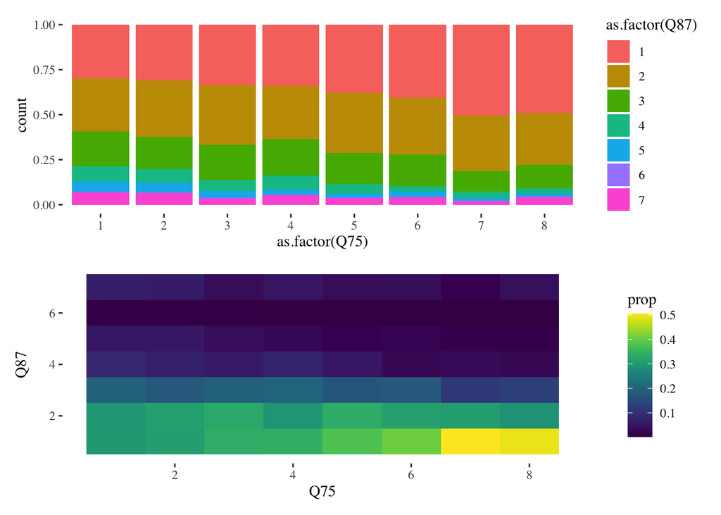

```r
# stacked
plot1 / plot2
```

# Other options

## Calculating polygon area

The `sf` package provides a way to calculate polygin area with minimal effort

```r
# mutate on a new column
# as.numeric(st_area(geom)) / 1e6) mutate on a new column

eji_data |>
  filter(STATE_NAME=="California") |>
  select(E_TOTPOP, geom) |>
  mutate(area_km2 = as.numeric(st_area(geom)/1e6))
```

```
Simple feature collection with 9109 features and 2 fields
Geometry type: MULTIPOLYGON
Dimension:     XY
Bounding box:  xmin: -124.4096 ymin: 32.53444 xmax: -114.1312 ymax: 42.00948
Geodetic CRS:  NAD83
First 10 features:
   E_TOTPOP                           geom    area_km2
1      3768 MULTIPOLYGON (((-121.309 38...   0.8536566
2      5903 MULTIPOLYGON (((-121.2734 3...   4.3431053
3      6511 MULTIPOLYGON (((-121.411 38... 138.8305033
4      4636 MULTIPOLYGON (((-121.3099 3...   2.0977132
5      4203 MULTIPOLYGON (((-121.373 37...   1.8751311
6      4245 MULTIPOLYGON (((-121.2664 3...   1.6853959
7      2856 MULTIPOLYGON (((-121.3133 3...   1.0448347
8      7182 MULTIPOLYGON (((-121.2951 3...   1.3359124
9      5272 MULTIPOLYGON (((-121.9224 3...   1.6167287
10     7211 MULTIPOLYGON (((-122.0451 3...   3.0173396
```

Let’s check visually to see if it worked the way we expect it to:

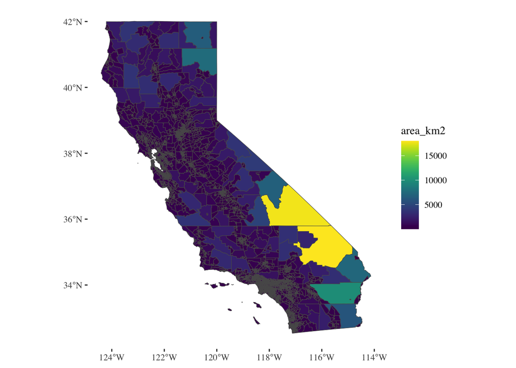

```r
eji_data |>
  filter(STATE_NAME=="California") |>
  select(E_TOTPOP, geom) |>
  mutate(area_km2 = as.numeric(st_area(geom)/1e6)) |>
  ggplot()+
  geom_sf(aes(fill=area_km2)) +
  scale_fill_viridis() +
  theme_tufte()
```

## Third variable

Using color:

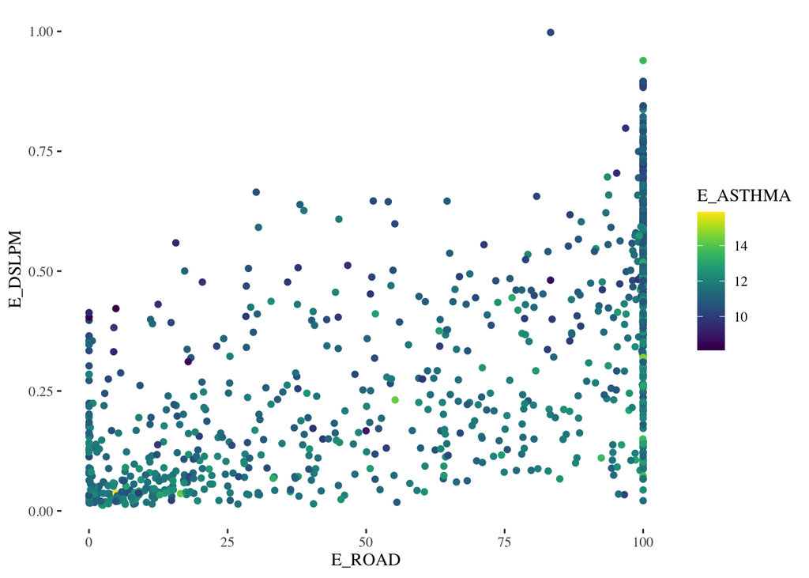

```r
eji_data |>
  filter(STATE_NAME=="Oregon") |>
  ggplot(aes(y=E_DSLPM, x=E_ROAD, color=E_ASTHMA)) +
  geom_point() +
  scale_color_viridis() +
  theme_tufte()
```

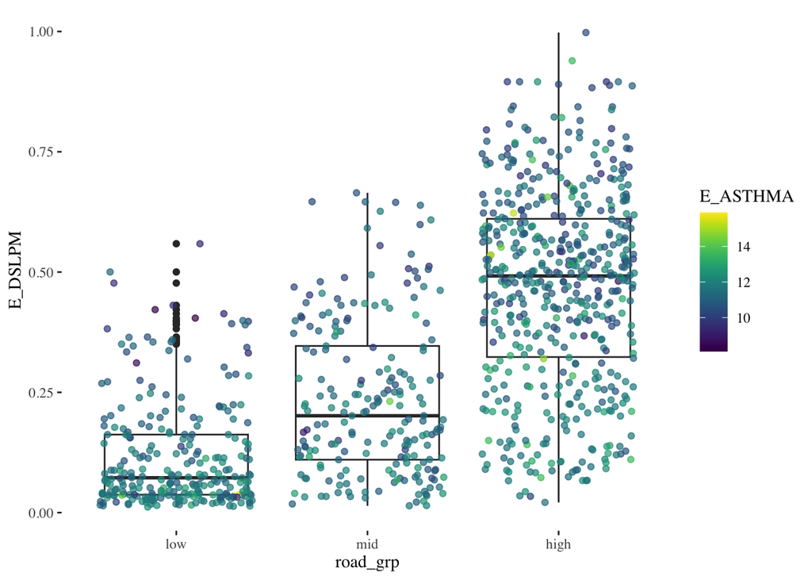

```r
eji_data |>
  filter(STATE_NAME=="Oregon") |>
  ggplot(aes(y=E_DSLPM, x=road_grp, color=E_ASTHMA)) +
  geom_boxplot() +
  geom_jitter(alpha=0.7) +
  scale_color_viridis() +
  theme_tufte()
```

Using size:

To use size to show a variable use the `size=variable` argument within `aes()`. Try it and see if it helps with anything. Color is usually the better choice, but sometimes not.